# Final Project Divvy

## Divvy Dataset

Historical trip data available to the public Here you’ll find Divvy’s trip data for public use. So whether you’re a policy maker, transportation professional, web developer, designer, or just plain curious, feel free to download it, map it, animate it, or bring it to life! Note that we’ll be releasing trip data twice a year: once following the end of calendar Q2 and once following the end of calendar Q4. This data is provided according to the Divvy Data License Agreement.

The Data Each trip is anonymized and includes: *Trip start day and time* Trip end day and time *Trip start station* Trip end station *Rider type (Member or 24-Hour Pass User)* If a Member trip, it will also include Member’s gender and year of birth Click the buttons on the right side of the page to download the available data sets. The folders also include a shapefile of our stations (and you can get live station info on our station JSON feed).

## Read the Dataset

Change the file path when working with a different computer

```r
Q1 <- read.csv(file="C:/Users/dglownia/Documents/GitHub/CSC-465-Data-Visualization-Divvy-Final-Project/Dataset/Divvy_Trips_2016_Q1Q2/Divvy_Trips_2016_Q1.csv",head=TRUE,sep=",")

April <- read.csv(file="C:/Users/dglownia/Documents/GitHub/CSC-465-Data-Visualization-Divvy-Final-Project/Dataset/Divvy_Trips_2016_Q1Q2/Divvy_Trips_2016_04.csv",head=TRUE,sep=",")

May <- read.csv(file="C:/Users/dglownia/Documents/GitHub/CSC-465-Data-Visualization-Divvy-Final-Project/Dataset/Divvy_Trips_2016_Q1Q2/Divvy_Trips_2016_05.csv",head=TRUE,sep=",")

June <- read.csv(file="C:/Users/dglownia/Documents/GitHub/CSC-465-Data-Visualization-Divvy-Final-Project/Dataset/Divvy_Trips_2016_Q1Q2/Divvy_Trips_2016_06.csv",head=TRUE,sep=",")

geo <- read.csv(file="C:/Users/dglownia/Documents/GitHub/CSC-465-Data-Visualization-Divvy-Final-Project/Dataset/Divvy_Trips_2016_Q1Q2/Divvy_Stations_2016_Q1Q2.csv",head=TRUE,sep=",")
```

```r
April$age <- (2016 - April$birthyear)

April$TripDurationHours <- floor(April$tripduration/60)

April$gender <- ifelse(April$usertype != "Customer", April$gender, 1 )

April <- April[!(April$gender == 1),]

April$gender <- ifelse(April$gender==2, "Female", "Male" )
```

```r
April$TripDurationHours <- paste(floor(April$tripduration/60),"hr")

April$ageCatagorical <- paste("Age: ", (floor(April$age/10) *10))
```

## Male vs Female ride habits

```r
library(xtable)
library(dplyr)
#Create new data frame for positive (spending) values
gender <- April %>% select(gender, ageCatagorical, TripDurationHours, tripduration) %>%
  group_by(gender, ageCatagorical, TripDurationHours) %>%
  summarize(tripduration = sum(tripduration, na.rm=FALSE))
```

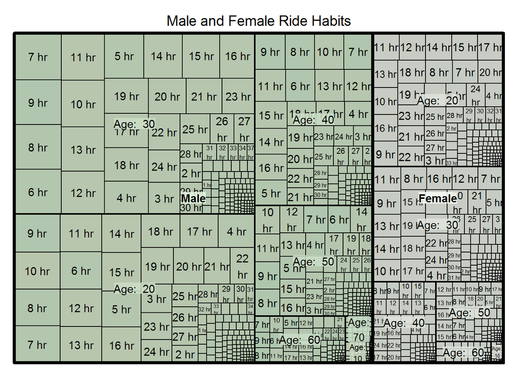

```r
library(treemap)
treemap(gender, #Your data frame object
        index=c("gender","ageCatagorical", "TripDurationHours"),  #A list of your categorical variables
        vSize = "tripduration",  #This is your quantitative variable
        type="index", #Type sets the organization and color scheme of your treemap
        palette = "Greens",  #Select your color palette from the RColorBrewer presets or make your own.
        title="Male and Female Ride Habits", #Customize your title
        fontsize.title = 14 #Change the font size of the title
        )
```

## Dataset

```r
set.seed(500)
library(MASS)
data <- Boston
```

## Data check and Cleaning

```r
apply(data,2,function(x) sum(is.na(x)))
```

```
##    crim      zn   indus    chas     nox      rm     age     dis     rad
##       0       0       0       0       0       0       0       0       0
##     tax ptratio   black   lstat    medv
##       0       0       0       0       0
```

## Pre-Processing (MSE-mean squared error, linear regression model)

We proceed by randomly splitting the data into a train and a test set, then we fit a linear regression model and test it on the test set. Note that I am using the gml() #function instead of the lm() this will become useful later when cross validating the linear model.

The sample(x,size) function simply outputs a vector of the specified size of randomly selected samples from the vector x. By default the sampling is without replacement: index is essentially a random vector of indeces. Since we are dealing with a regression problem, we are going to use the mean squared error (MSE) as a measure of how much our predictions are far away from the real data.

```r
index <- sample(1:nrow(data),round(0.75*nrow(data)))
train <- data[index,]
test <- data[-index,]
lm.fit <- glm(medv~., data=train)
summary(lm.fit)
```

```
##
## Call:
## glm(formula = medv ~ ., data = train)
##
## Deviance Residuals:
##      Min        1Q    Median        3Q       Max
## -14.9143   -2.8607   -0.5244    1.5242   25.0004
##
## Coefficients:
##               Estimate Std. Error t value Pr(>|t|)
## (Intercept)  43.469681   6.099347   7.127 5.50e-12 ***
## crim         -0.105439   0.057095  -1.847 0.065596 .
## zn            0.044347   0.015974   2.776 0.005782 **
## indus         0.024034   0.071107   0.338 0.735556
## chas          2.596028   1.089369   2.383 0.017679 *
## nox         -22.336623   4.572254  -4.885 1.55e-06 ***
## rm            3.538957   0.472374   7.492 5.15e-13 ***
## age           0.016976   0.015088   1.125 0.261291
## dis          -1.570970   0.235280  -6.677 9.07e-11 ***
## rad           0.400502   0.085475   4.686 3.94e-06 ***
## tax          -0.015165   0.004599  -3.297 0.001072 **
## ptratio      -1.147046   0.155702  -7.367 1.17e-12 ***
## black         0.010338   0.003077   3.360 0.000862 ***
## lstat        -0.524957   0.056899  -9.226  < 2e-16 ***
## ---
## Signif. codes:  0 '***' 0.001 '**' 0.01 '*' 0.05 '.' 0.1 ' ' 1
##
## (Dispersion parameter for gaussian family taken to be 23.26491)
##
##     Null deviance: 33642  on 379  degrees of freedom
## Residual deviance:  8515  on 366  degrees of freedom
## AIC: 2290
##
## Number of Fisher Scoring iterations: 2
```

```r
pr.lm <- predict(lm.fit,test)
MSE.lm <- sum((pr.lm - test$medv)^2)/nrow(test)
```

## Preparing to fit the neural network

```r
maxs <- apply(data, 2, max)
mins <- apply(data, 2, min)

scaled <- as.data.frame(scale(data, center = mins, scale = maxs - mins))

train_ <- scaled[index,]
test_ <- scaled[-index,]
```

## Parameters

```r
library(neuralnet)
n <- names(train_)
f <- as.formula(paste("medv ~", paste(n[!n %in% "medv"], collapse = " + ")))
nn <- neuralnet(f,data=train_,hidden=c(5,3),linear.output=T)
```

## Visualizing the neural network

```r
plot(nn)
```

[output not shown]

## Predicting medv using the neural network

print the MSE at the end

```r
pr.nn <- compute(nn,test_[,1:13])

pr.nn_ <- pr.nn$net.result*(max(data$medv)-min(data$medv))+min(data$medv)
test.r <- (test_$medv)*(max(data$medv)-min(data$medv))+min(data$medv)

MSE.nn <- sum((test.r - pr.nn_)^2)/nrow(test_)

print(paste(MSE.lm,MSE.nn))
```

```
## [1] "21.6297593507225 15.7518370200153"
```

## Visualizing the MSE NN vs Linear Model

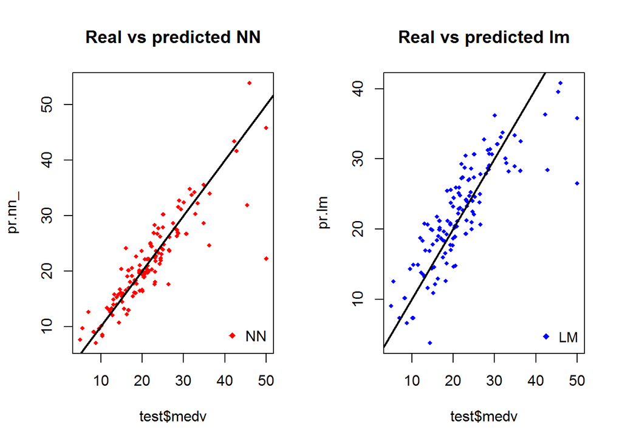

```r
par(mfrow=c(1,2))

plot(test$medv,pr.nn_,col='red',main='Real vs predicted NN',pch=18,cex=0.7)
abline(0,1,lwd=2)
legend('bottomright',legend='NN',pch=18,col='red', bty='n')

plot(test$medv,pr.lm,col='blue',main='Real vs predicted lm',pch=18, cex=0.7)
abline(0,1,lwd=2)
legend('bottomright',legend='LM',pch=18,col='blue', bty='n', cex=.95)
```

## Vsualizing the Real vd Predicted

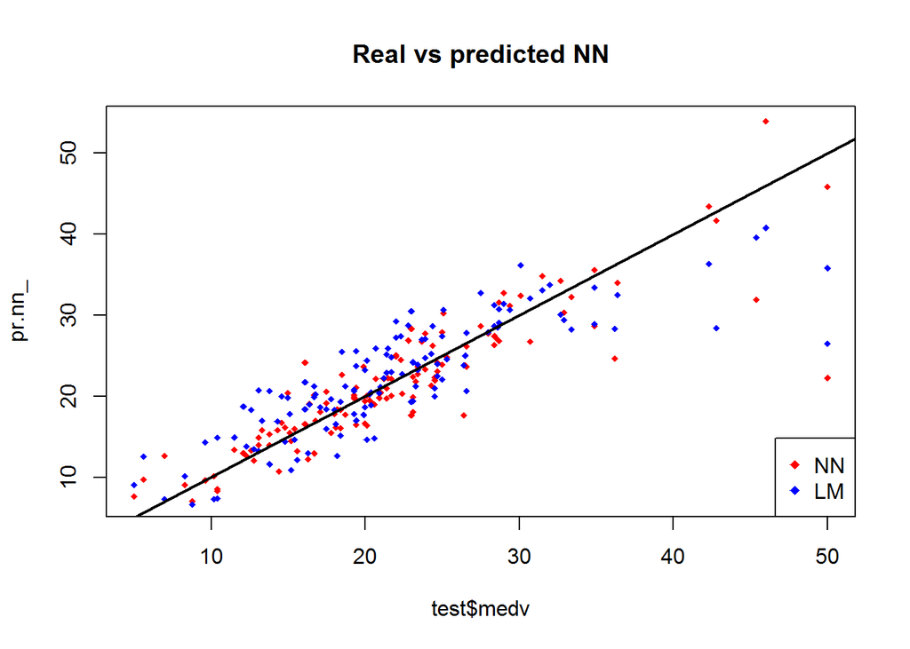

```r
plot(test$medv,pr.nn_,col='red',main='Real vs predicted NN',pch=18,cex=0.7)
points(test$medv,pr.lm,col='blue',pch=18,cex=0.7)
abline(0,1,lwd=2)
legend('bottomright',legend=c('NN','LM'),pch=18,col=c('red','blue'))
```

## A (fast) cross validation

Order of operations - train-test split - Do the train-test split - Fit the model to the train set - Test the model on the test set - Calculate the prediction error - Repeat the process K times

```r
library(boot)
set.seed(200)
lm.fit <- glm(medv~.,data=data)
cv.glm(data,lm.fit,K=10)$delta[1]
```

```
## [1] 23.83560156
```

Now the net. Note that I am splitting the data in this way: 90% train set and 10% test set in a random way for 10 times. I am also initializing a progress bar using the plyr library because I want to keep an eye on the status of the process since the fitting of the neural network may take a while.

```r
set.seed(450)
cv.error <- NULL
k <- 10

library(plyr)
pbar <- create_progress_bar('text')
pbar$init(k)
for(i in 1:k){
    index <- sample(1:nrow(data),round(0.9*nrow(data)))
    train.cv <- scaled[index,]
    test.cv <- scaled[-index,]

    nn <- neuralnet(f,data=train.cv,hidden=c(5,2),linear.output=T)

    pr.nn <- compute(nn,test.cv[,1:13])
    pr.nn <- pr.nn$net.result*(max(data$medv)-min(data$medv))+min(data$medv)

    test.cv.r <- (test.cv$medv)*(max(data$medv)-min(data$medv))+min(data$medv)

    cv.error[i] <- sum((test.cv.r - pr.nn)^2)/nrow(test.cv)

    pbar$step()
}
```

After a while, the process is done, we calculate the average MSE and plot the results as a boxplot

```r
mean(cv.error)
```

```
## [1] 10.32697995
```

```r
cv.error
```

```
##  [1] 17.640652805  6.310575067 15.769518577  5.730130820 10.520947119
##  [6]  6.121160840  6.389967211  8.004786424 17.369282494  9.412778105
```

# Box Plot Visualization

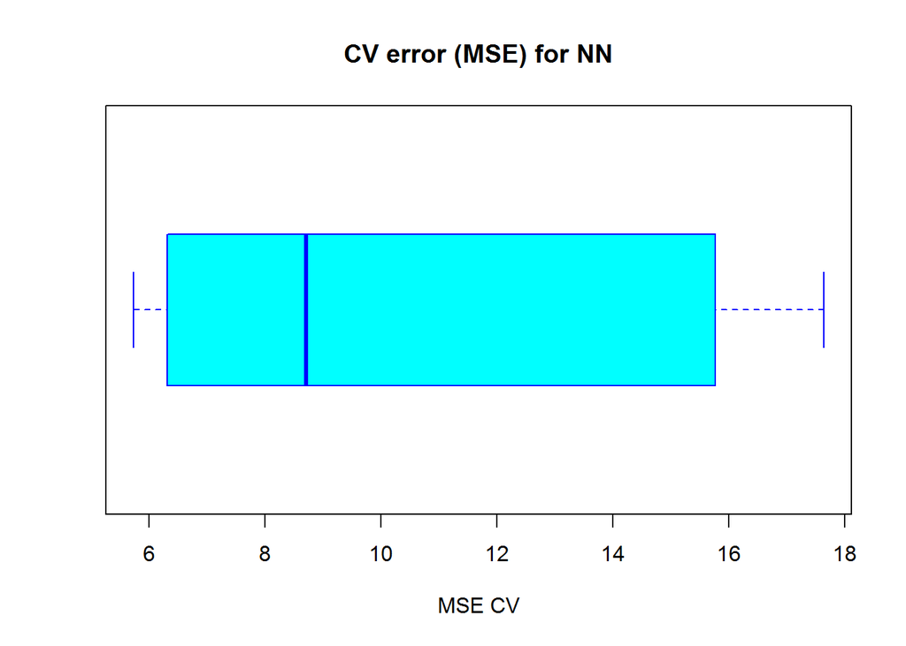

```r
boxplot(cv.error,xlab='MSE CV',col='cyan',
        border='blue',names='CV error (MSE)',
        main='CV error (MSE) for NN',horizontal=TRUE)
```